# Trabalhos Finais de Diagnóstico Ambiental

Análise Ambiental · Aula 16.1

Prof. Dr. Luiz Diego Vidal Santos

## Abertura Visão Geral da Aula

**01 · Termo de Referência (TR):** estrutura obrigatória do Relatório Técnico Final de Análise Ambiental.

**02 · Rito de Defesa:** Seminário de Defesa Técnica em formato de Câmara Técnica / INEMA / CBH.

**03 · Rubrica de Avaliação:** critérios de excelência do Relatório Escrito ($25\%$) e da Defesa Oral ($20\%$).

**04 · Síntese das 16 Semanas:** a Caixa de Ferramentas do Geógrafo Analista Ambiental.

**05 · Ética e Carreira:** Responsabilidade Técnica (CREA/ART) e perspectivas de atuação profissional.

Objetivo da Aula Defesa técnica e síntese formativa

Conduzir a defesa pública dos **Diagnósticos e Planos de Intervenção Ambiental** elaborados pelas equipes ao longo da Unidade III e consolidar a síntese profissional das competências do Bacharel em Geografia na área de Análise e Planejamento Ambiental.

Relatório 25% Defesa Oral 20% Matriz FPEIR & IPI CREA / ART

# Estrutura do Trabalho Prático Final

## Termo de Ref. Seções Obrigatórias do Documento Técnico

01 · Identificação e Escopo Recorte territorial

Título, localização da sub-bacia ou gleba estudada (mapa de localização em **SIRGAS 2000**), justificativa e objetivos.

02 · Diagnóstico Integrado Meios Físico, Biótico e Socioeconômico

- **Físico:** geologia, geomorfologia/declividade, morfometria ($K_c, K_f, D_d$), clima e solos (SiBCS / topossequência).
- **Biótico e Uso:** fitofisionomia, MapBiomas e situação legal de APPs/RL (Lei 12.651/2012).
- **Socioeconômico:** usos da água, conflitos territoriais e pressões antrópicas.

03 · Fragilidade e FPEIR Avaliação integrada

Classificação da **Fragilidade Emergente (Ross, 1994)** ou **Vulnerabilidade Natural (Crepani, 2001)**, Capacidade de Uso (Lepsch, 2015) e indicadores de água/solo.

04 · Zoneamento e Intervenção Proposta de PRAD / SbN

Medidas preventivas, mitigadoras, de bioengenharia e de restauração ecológica espacializadas, com matriz de indicadores de monitoramento.

## Termo de Ref. Fluxo Metodológico do Trabalho Prático Final

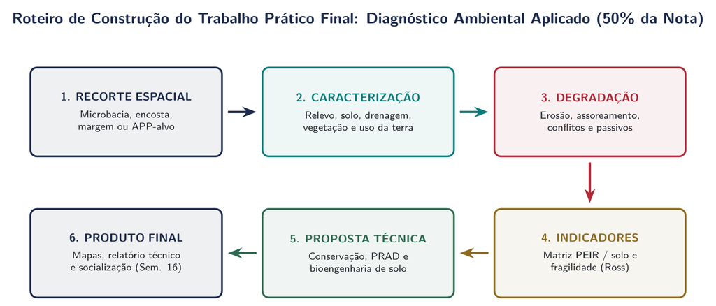

Fluxo metodológico em seis etapas para construção do Trabalho Prático Final de Diagnóstico Ambiental Aplicado.

Roteiro de Construção do Trabalho Prático Final (50% da Nota) Encadeamento do recorte espacial, caracterização, degradação, indicadores e proposta técnica até a entrega final

## Cartografia Produtos Cartográficos e Técnicos Exigidos

Carta 1 Base Física e Drenagem

Mapa de Localização, Hipsometria e Rede de Drenagem hierarquizada (**Strahler**).

Carta 2 Declividade e Uso

Mapa de Declividade (classes de Ross: $<6\%$ a $>30\%$) e Uso/Cobertura da Terra.

Carta 3 · Síntese Fragilidade e APP

Carta de Fragilidade Ambiental Emergente ou Zoneamento de Intervenção/Conflito Legal em APP.

Anexo de Campo Evidências in situ

Fichas de Diagnóstico Rápido preenchidas nas estações amostrais + Prancha Fotográfica comentada.

Todos os produtos cartográficos devem observar convenções completas: grade de coordenadas, legenda hierarquizada, escala gráfica, orientação norte, fonte oficial e datum **SIRGAS 2000**.

## Priorização Índice Composto de Priorização (IPI) no Diagnóstico Final

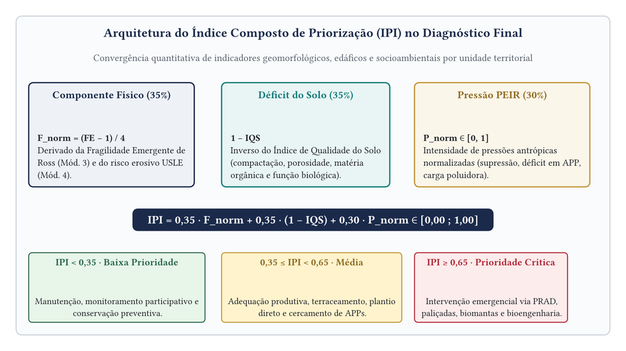

Arquitetura do Índice Composto de Priorização (IPI) combinando Componente Físico, Déficit do Solo e Pressão PEIR para definição de prioridades de intervenção.

Arquitetura do Índice Composto de Priorização (IPI) Convergência quantitativa entre Fragilidade Emergente (Ross), Déficit do Solo (1 − IQS) e Pressão PEIR

# Rito de Defesa e Rubrica de Avaliação

## Defesa Formato de “Câmara Técnica / Audiência”

Cronômetro da sessão Tempo por equipe

- **$15\text{ minutos}$** de exposição técnica objetiva (todos os integrantes devem apresentar ao menos uma etapa do estudo);
- **$5\text{ a }10\text{ minutos}$** de arguição pela banca (docente + colegas atuando como analistas do órgão ambiental / comitê de bacia).

Diretriz de apresentação Foco da exposição

- Evitar longas introduções teóricas gerais;
- Ir direto à **caracterização da área, às evidências de campo, à cadeia causal dos impactos diagnosticados (FPEIR) e à viabilidade técnica/legal das soluções propostas**.

## Avaliação Rubrica de Avaliação do Trabalho Final

| Dimensão Avaliada | Peso | Critérios de Excelência |
| --- | --- | --- |
| **1. Rigor do Diagnóstico Integrado e Cartografia** | **$30\%$** | Integração real entre relevo, solo, hidrologia e uso da terra; mapas com convenções cartográficas completas (grade, legenda, escala, norte, fonte e datum SIRGAS 2000). |
| **2. Coerência dos Indicadores e Enquadramento Legal** | **$25\%$** | Aplicação correta da matriz FPEIR, das classes de Ross/Crepani/Lepsch e das normas (Lei 12.651/2012, CONAMA 357/2005, IN IBAMA 14/2024). |
| **3. Qualidade Técnica da Proposta (PRAD / SbN)** | **$25\%$** | Especificidade das técnicas de bioengenharia e restauração recomendadas para cada compartimento da vertente/canal (sem “receitas genéricas”). |
| **4. Clareza, Postura Técnica e Resposta à Arguição** | **$20\%$** | Domínio oral, precisão terminológica, cumprimento do tempo e capacidade de sustentar tecnicamente as recomendações. |

# Síntese Geral da Disciplina

## Síntese A Caixa de Ferramentas do Geógrafo Analista Ambiental

Unidade I · Aulas 1.1 a 5.1 Fundamentos, Conceitos e Licenciamento

- **Epistemologia Sociedade$\leftrightarrow$Natureza:** Santos, Porto-Gonçalves, Leff, Ab’Sáber, Monteiro, Mendonça e Suertegaray.
- **Impacto, Resiliência e Risco:** equação $R = P \times E \times V$ e setorização R1–R4.
- **Marco Legal:** PNMA (Lei 6.938/81) e rito de AIA/EIA-RIMA.

Unidade II · Aulas 6.1 a 10.1 Análise Integrada, Bacias e Geossistemas

- **Escalas e Ordenamento:** compatibilidade de escalas (Castro, 1995) e ZEE (Dec. 4.297/02).
- **Bacias e Vertentes:** morfometria, Lei das Águas (Lei 9.433/97) e morfopedologia (Boulet, RUSLE, movimentos de massa).
- **Síntese:** Ecodinâmica (Tricart), Fragilidade (Ross) e Vulnerabilidade (Crepani).

Unidade III · Aulas 11.1 a 16.1 Indicadores, Degradação e Legislação

- **Monitoramento e Solos:** Matriz FPEIR, IQA, IET, CONAMA 357/05, SiBCS, Capacidade de Uso (I–VIII) e CONAMA 420/09.
- **Processos e Técnicas:** mecanística de voçorocas, pinos/VANT e SbN/Bioengenharia.
- **Normas:** Código Florestal, SNUC, PNPSA e PRAD (IN IBAMA 14/2024).

**Percurso das 16 semanas:** articular fundamentos epistemológicos, modelagem biofísica multiescalar e engenharia normativa para produzir diagnósticos ambientais auditáveis e socialmente justos.

## Ética e CREA Ética Profissional, CREA/ART e Caminhos de Atuação

Leis nº 6.664/1979 e nº 6.496/1977 Rigor científico e independência técnica

Um parecer ambiental, EIA/RIMA ou laudo pericial assinado por um Geógrafo (com recolhimento de **ART junto ao CREA**) decide sobre a segurança hídrica, a estabilidade de encostas e os direitos territoriais de populações inteiras.

Art. 69-A da Lei nº 9.605/1998 Jamais omitir impactos ou riscos

A omissão dolosa ou culposa de informações relevantes em estudos de licenciamento configura crime ambiental: elaborar ou apresentar estudo, laudo ou relatório ambiental total ou parcialmente falso ou enganoso.

Mensagem Final de Encerramento O olhar integrador da Geografia

A **Geografia** é uma das poucas ciências capazes de ler simultaneamente a **estrutura mineral da rocha**, a **hidrodinâmica do poro do solo**, a **morfometria da bacia hidrográfica** e as **relações sociais de poder no território**.

Levem essa capacidade de síntese integrada para a pesquisa, para o serviço público e para o planejamento ambiental do Brasil e da Bahia!